# Relationship Of Storm Severity On

# Fatality And Property Damage In The US

Peter Pih  
Reproducible Research, Coursera (repdata-015)  
June 18th, 2015

## **Synopsis**

This study considers which types of severe weather conditions have the greatest impact on fatality and property damage rates in the US between 1950-2011. Of the 48 NOAA categories for severe weather incidents, the five causing the most severe fatalities, injuries, property damage, and crop damage are identified. We find that Fatalities and Injuries are dominated by tornadoes and heat; Property and Crops by flooding and precipitation, though tornadoes are in the top 5 contributors to damage for these latter two. This would indicate that differing methods may be necessary to mitigate future damage costs. We also show a potentially alarming trend in property damage which has been trend increasing since the 1990’s.

## **Overview**

This report is an evaluation of the Storm Data data set[1], for which we consider damage rates for fatalities, injuries, property, and crops during severe weather events.

We are asked to answer the following two questions:

- Across the United States, which types of events (as indicated in the EVTYPE variable) are most harmful with respect to population health?
- Across the United States, which types of events have the greatest economic consequences?

For the purpose of this study, we define **harmful to population health** as death and injury. These are direct effects of the storms on people, we do not include secondary environmental effects in this definition, ie contamination of water and food supplies, loss of medical coverage, etc.

For the purposes of this study, we define **economic consequences** as direct damage to property. The two main categories in the data set are: property damage and crop damage.

Sections in thie report:

1. Function Declarations - internal functions used for data processing for this report
2. Data Processing and Modifications
3. Severe Weather Impact On Fatalities And Injuries
4. Severe Weather Impact On Property And Crop Damage
5. Results

## **Function Declarations**

These are descriptions of functions used in this study. We use several functions to process the data which allows for consistent, uniform, and repeatable processing.

- evtype_aggregate()
- evtype_reclassify()
- by_year()

**evtype_aggregate function**

Sums up the variable of interest (FATALITIES, INJURIES, PROPDMG, CROPDMG) and ranks EVTYPE by this sum.

```r
evtype_aggregate <- function(x, field="FATALITIES"){
    result <- data.frame()
    types_u <- unique(x$EVTYPE)
    for (i in types_u){
        type_subset <- subset(x, x$EVTYPE == i)

        if (field == "FATALITIES") t_sum <- sum(type_subset$FATALITIES)
        else if (field == "INJURIES") t_sum <- sum(type_subset$INJURIES)
        else if (field == "PROPERTY") t_sum <- sum(type_subset$PROPDMG)
        else if (field == "CROPS") t_sum <- sum(type_subset$CROPDMG)

        result <- rbind(result, data.frame(EVTYPE=i, count=nrow(type_subset), sum=t_sum))
    }

    result<-result[with(result, order(-result$sum)),]   # sort the totals descending, the worst on top
    #
    # Add a column for average cost per incident
    #
    result <- cbind(result, avg=as.integer(result$sum/result$count+0.5))
    #
    # Add a column for the % of sum for each row
    #
    result <- cbind(result, pct=round(result$sum/sum(result$sum)*100, 2))

    result
}
```

**by_year() function**

Creates a data.frame of the number of incidents in a given year denoted in **BGN_DATE** which should contain the year an incident occurred.

```r
by_year <- function(x){
    result <- data.frame()                # initialize output data.frame
    y <- unique(x$BGN_DATE)               # get unique years
    for (i in y){
        y_subset <- subset(x, x$BGN_DATE == i)
        result <- rbind(result, data.frame(year=i, count=nrow(y_subset)))
    }
    result
}
```

**evtype_reclassify() function**

This function is used to tidy up and help group labels into a parsimonious number of categories. There are several dominant categories, ie TORNADO, which have not been modified from the original.

The reclassification takes into account the suggested 48 NOAA catagories and further reduces them based on a heuristic criterias: duration, similarity, predictability, preventability, amoung oter criteria. For example, tempurature effects like **HEAT** tend to last on the order of days, as opposed to dynamic effects like **TORNADO** which last on the order of hours. Another example of grouping criteria is time predictability. Ground movement **LANDSLIDES** are very difficult to predict, whereas coastal conditions **SURF** can be predicted or warned in advance (though the magnitude may not be reliably predicted). Another example is precipitation **PRECIP** which is basically things falling from the sky like rain, snow, and hail.

Admittedly, several of the categories will have high corrleations of incidence with each other ie **WIND** and **SURF**, or **ICE** and **COLD**.

It is notable that on initial inspection of the EVTYPE categories without modification, several of the original categories stood out as being associated with large amounts of damage or injury, ie **TORNADO**

This reclassification table is not a comprehensive list covering all the EVTYPEs of the entire Storm Data set. It is derived from the subsets of interest (**fatal_injury**, **property_crop**), and is formed by those observations that have damage values or fatalities reported as greater than 0. **This table may need to be updated as new data is added to the Storm Data set**.

```r
evtype_reclassify <- function(x) {

    x$EVTYPE <- as.character(x$EVTYPE)

    x$EVTYPE[grepl("TORNADO", x$EVTYPE, ignore.case=TRUE)] <-"TORNADO"
    x$EVTYPE[grepl("FUNNEL CLOUD", x$EVTYPE, ignore.case=TRUE)] <-"TORNADO"
    x$EVTYPE[grepl("TORNDAO", x$EVTYPE, ignore.case=TRUE)] <-"TORNADO"
    x$EVTYPE[grepl("HEAT", x$EVTYPE, ignore.case=TRUE)] <-"HEAT"
    x$EVTYPE[grepl("WARM", x$EVTYPE, ignore.case=TRUE)] <-"HEAT"
    x$EVTYPE[grepl("HYPERTHERMIA", x$EVTYPE, ignore.case=TRUE)] <-"HEAT"
    x$EVTYPE[grepl("COLD", x$EVTYPE, ignore.case=TRUE)] <-"COLD"
    x$EVTYPE[grepl("LOW TEMPERATURE", x$EVTYPE, ignore.case=TRUE)] <-"COLD"
    x$EVTYPE[grepl("HYPOTHERMIA", x$EVTYPE, ignore.case=TRUE)] <-"COLD"
    x$EVTYPE[grepl("FREEZE", x$EVTYPE, ignore.case=TRUE)] <-"COLD"
    x$EVTYPE[grepl("COOL AND WET", x$EVTYPE, ignore.case=TRUE)] <-"COLD"
    x$EVTYPE[grepl("WIND", x$EVTYPE, ignore.case=TRUE)] <-"WIND"
    x$EVTYPE[grepl("HIGH", x$EVTYPE, ignore.case=TRUE)] <-"WIND"
    x$EVTYPE[grepl("DOWNBURST", x$EVTYPE, ignore.case=TRUE)] <-"WIND"
    x$EVTYPE[grepl("SEVERE TURBULENCE", x$EVTYPE, ignore.case=TRUE)] <-"WIND"
    x$EVTYPE[grepl("GUSTNADO", x$EVTYPE, ignore.case=TRUE)] <-"WIND"
    x$EVTYPE[grepl("FLOOD", x$EVTYPE, ignore.case=TRUE)] <-"FLOOD"
    x$EVTYPE[grepl("FLD", x$EVTYPE, ignore.case=TRUE)] <-"FLOOD"
    x$EVTYPE[grepl("HIGH WATER", x$EVTYPE, ignore.case=TRUE)] <-"FLOOD"
    x$EVTYPE[grepl("RAPIDLY RISING WATER", x$EVTYPE, ignore.case=TRUE)] <-"FLOOD"
    x$EVTYPE[grepl("DAM BREAK", x$EVTYPE, ignore.case=TRUE)] <-"FLOOD"
    x$EVTYPE[grepl("SNOW", x$EVTYPE, ignore.case=TRUE)] <- "PRECIP"
    x$EVTYPE[grepl("RAIN", x$EVTYPE, ignore.case=TRUE)] <-"PRECIP"
    x$EVTYPE[grepl("STORM", x$EVTYPE, ignore.case=TRUE)] <-"PRECIP"
    x$EVTYPE[grepl("HAIL", x$EVTYPE, ignore.case=TRUE)] <-"PRECIP"
    x$EVTYPE[grepl("BLIZZARD", x$EVTYPE, ignore.case=TRUE)] <-"PRECIP"
    x$EVTYPE[grepl("WINTER", x$EVTYPE, ignore.case=TRUE)] <-"PRECIP"
    x$EVTYPE[grepl("SLEET", x$EVTYPE, ignore.case=TRUE)] <-"PRECIP"
    x$EVTYPE[grepl("HEAVY SHOWER", x$EVTYPE, ignore.case=TRUE)] <-"PRECIP"
    x$EVTYPE[grepl("MIXED PRECIP", x$EVTYPE, ignore.case=TRUE)] <-"PRECIP"
    x$EVTYPE[grepl("WINTRY MIX", x$EVTYPE, ignore.case=TRUE)] <-"PRECIP"
    x$EVTYPE[grepl("DRIZZLE", x$EVTYPE, ignore.case=TRUE)] <-"PRECIP"
    x$EVTYPE[grepl("TSTWM", x$EVTYPE, ignore.case=TRUE)] <-"PRECIP"
    x$EVTYPE[grepl("HEAVY PRECIPITATION", x$EVTYPE, ignore.case=TRUE)] <-"PRECIP"
    x$EVTYPE[grepl("MICROBURST", x$EVTYPE, ignore.case=TRUE)] <-"PRECIP"
    x$EVTYPE[grepl("HEAVY MIX", x$EVTYPE, ignore.case=TRUE)] <-"PRECIP"
    x$EVTYPE[grepl("EXCESSIVE WETNESS", x$EVTYPE, ignore.case=TRUE)] <-"PRECIP"
    x$EVTYPE[grepl("AVALANCE", x$EVTYPE, ignore.case=TRUE)] <-"LANDSLIDE"
    x$EVTYPE[grepl("AVALANCHE", x$EVTYPE, ignore.case=TRUE)] <-"LANDSLIDE"
    x$EVTYPE[grepl("LANDSLIDES", x$EVTYPE, ignore.case=TRUE)] <-"LANDSLIDE"
    x$EVTYPE[grepl("MUDSLIDE", x$EVTYPE, ignore.case=TRUE)] <-"LANDSLIDE"
    x$EVTYPE[grepl("MUD SLIDE", x$EVTYPE, ignore.case=TRUE)] <-"LANDSLIDE"
    x$EVTYPE[grepl("ROCK SLIDE", x$EVTYPE, ignore.case=TRUE)] <-"LANDSLIDE"
    x$EVTYPE[grepl("LANDSLUMP", x$EVTYPE, ignore.case=TRUE)] <-"LANDSLIDE"
    x$EVTYPE[grepl("HEAVY SEAS", x$EVTYPE, ignore.case=TRUE)] <-"SURF"
    x$EVTYPE[grepl("HIGH SEAS", x$EVTYPE, ignore.case=TRUE)] <-"SURF"
    x$EVTYPE[grepl("HIGH SURF", x$EVTYPE, ignore.case=TRUE)] <-"SURF"
    x$EVTYPE[grepl("HIGH WAVES", x$EVTYPE, ignore.case=TRUE)] <-"SURF"
    x$EVTYPE[grepl("HIGH SWELL", x$EVTYPE, ignore.case=TRUE)] <-"SURF"
    x$EVTYPE[grepl("HEAVY SURF", x$EVTYPE, ignore.case=TRUE)] <-"SURF"
    x$EVTYPE[grepl("WATERSPOUT", x$EVTYPE, ignore.case=TRUE)] <-"SURF"
    x$EVTYPE[grepl("ROUGH SURF", x$EVTYPE, ignore.case=TRUE)] <-"SURF"
    x$EVTYPE[grepl("ROUGH SEAS", x$EVTYPE, ignore.case=TRUE)] <-"SURF"
    x$EVTYPE[grepl("RIP CURRENT", x$EVTYPE, ignore.case=TRUE)] <-"SURF"
    x$EVTYPE[grepl("MARINE MISHAP", x$EVTYPE, ignore.case=TRUE)] <-"SURF"
    x$EVTYPE[grepl("MARINE ACCIDENT", x$EVTYPE, ignore.case=TRUE)] <-"SURF"
    x$EVTYPE[grepl("HAZARDOUS SURF", x$EVTYPE, ignore.case=TRUE)] <-"SURF"
    x$EVTYPE[grepl("ROGUE WAVE", x$EVTYPE, ignore.case=TRUE)] <-"SURF"
    x$EVTYPE[grepl("TSUNAMI", x$EVTYPE, ignore.case=TRUE)] <-"SURF"
    x$EVTYPE[grepl("DROWNING", x$EVTYPE, ignore.case=TRUE)] <-"SURF"
    x$EVTYPE[grepl("COASTAL", x$EVTYPE, ignore.case=TRUE)] <-"SURF"
    x$EVTYPE[grepl("LOW TIDE", x$EVTYPE, ignore.case=TRUE)] <-"SURF"
    x$EVTYPE[grepl("HEAVY SWELLS", x$EVTYPE, ignore.case=TRUE)] <-"SURF"
    x$EVTYPE[grepl("ICE FLOES", x$EVTYPE, ignore.case=TRUE)] <-"SURF"
    x$EVTYPE[grepl("SEICHE", x$EVTYPE, ignore.case=TRUE)] <-"SURF"
    x$EVTYPE[grepl("BEACH EROSION", x$EVTYPE, ignore.case=TRUE)] <-"SURF"
    x$EVTYPE[grepl("GLAZE", x$EVTYPE, ignore.case=TRUE)] <-"ICE"
    x$EVTYPE[grepl("ICY ROADS", x$EVTYPE, ignore.case=TRUE)] <-"ICE"
    x$EVTYPE[grepl("BLACK ICE", x$EVTYPE, ignore.case=TRUE)] <-"ICE"
    x$EVTYPE[grepl("ICE ROAD", x$EVTYPE, ignore.case=TRUE)] <-"ICE"
    x$EVTYPE[grepl("ICE ON ROAD", x$EVTYPE, ignore.case=TRUE)] <-"ICE"
    x$EVTYPE[grepl("FREEZING SPRAY", x$EVTYPE, ignore.case=TRUE)] <-"ICE"
    x$EVTYPE[grepl("FROST", x$EVTYPE, ignore.case=TRUE)] <-"ICE"
    x$EVTYPE[grepl("ICE JAM", x$EVTYPE, ignore.case=TRUE)] <-"ICE"
    x$EVTYPE[grepl("FIRE", x$EVTYPE, ignore.case=TRUE)] <-"FIRE"
    x$EVTYPE[grepl("DROUGHT", x$EVTYPE, ignore.case=TRUE)] <-"FIRE"
    x$EVTYPE[grepl("FOG", x$EVTYPE, ignore.case=TRUE)] <-"VISIBILITY"
    x$EVTYPE[grepl("DRY MICROBURST", x$EVTYPE, ignore.case=TRUE)] <-"VISIBILITY"
    x$EVTYPE[grepl("DUST DEVIL", x$EVTYPE, ignore.case=TRUE)] <-"VISIBILITY"
    x$EVTYPE[grepl("BLOWING DUST", x$EVTYPE, ignore.case=TRUE)] <-"VISIBILITY"
    x$EVTYPE[grepl("DENSE SMOKE", x$EVTYPE, ignore.case=TRUE)] <-"VISIBILITY"
    x$EVTYPE[grepl("VOLCANIC", x$EVTYPE, ignore.case=TRUE)] <-"VISIBILITY"
    x$EVTYPE[grepl("HURRICANE", x$EVTYPE, ignore.case=TRUE)] <-"HURRICANE"
    x$EVTYPE[grepl("TYPHOON", x$EVTYPE, ignore.case=TRUE)] <-"HURRICANE"
    x$EVTYPE[grepl("TROPICAL", x$EVTYPE, ignore.case=TRUE)] <-"HURRICANE"
    x$EVTYPE[grepl("LIGHTNING", x$EVTYPE, ignore.case=TRUE)] <-"LIGHTNING"
    x$EVTYPE[grepl("LIGHTING", x$EVTYPE, ignore.case=TRUE)] <-"LIGHTNING"
    x$EVTYPE[grepl("LIGNTNING", x$EVTYPE, ignore.case=TRUE)] <-"LIGHTNING"
    x$EVTYPE[grepl("OTHER", x$EVTYPE, ignore.case=TRUE)] <-"OTHER"
    x$EVTYPE[grepl("URBAN", x$EVTYPE, ignore.case=TRUE)] <-"OTHER"
    return(x)
}
```

## **Data Processing and Modifications**

The main steps in processing and modifying the data set are:

1. Copy the original data set to a local directory
2. Read in the original data set
3. Extract the two broad portions of interest: **fatalities/injuries** and **property/crops**
4. Modify category groupings of events using **evtype_reclassify()**
5. Convert event date(s)
6. Further separate into **fatal_** or **injury_** and **property_** or **crop_**
7. Identify the top 10 or so impacts by event type and graph the top 5

Read in the original data set which is a compressed .csv file that has been copied to a subdirectory data/

```r
storm_data <- read.csv("data/repdata-data-StormData.csv.bz2")
dim(storm_data)
```

```
## [1] 902297     37
```

```r
str(storm_data)
```

```
## 'data.frame':    902297 obs. of  37 variables:
##  $ STATE__   : num  1 1 1 1 1 1 1 1 1 1 ...
##  $ BGN_DATE  : Factor w/ 16335 levels "1/1/1966 0:00:00",..: 6523 6523 4242 11116 2224 2224 2260 383 3980 3980 ...
##  $ BGN_TIME  : Factor w/ 3608 levels "00:00:00 AM",..: 272 287 2705 1683 2584 3186 242 1683 3186 3186 ...
##  $ TIME_ZONE : Factor w/ 22 levels "ADT","AKS","AST",..: 7 7 7 7 7 7 7 7 7 7 ...
##  $ COUNTY    : num  97 3 57 89 43 77 9 123 125 57 ...
##  $ COUNTYNAME: Factor w/ 29601 levels "","5NM E OF MACKINAC BRIDGE TO PRESQUE ISLE LT MI",..: 13513 1873 4598 10592 4372 10094 1973 23873 24418 4598 ...
##  $ STATE     : Factor w/ 72 levels "AK","AL","AM",..: 2 2 2 2 2 2 2 2 2 2 ...
##  $ EVTYPE    : Factor w/ 985 levels "   HIGH SURF ADVISORY",..: 834 834 834 834 834 834 834 834 834 834 ...
##  $ BGN_RANGE : num  0 0 0 0 0 0 0 0 0 0 ...
##  $ BGN_AZI   : Factor w/ 35 levels "","  N"," NW",..: 1 1 1 1 1 1 1 1 1 1 ...
##  $ BGN_LOCATI: Factor w/ 54429 levels "","- 1 N Albion",..: 1 1 1 1 1 1 1 1 1 1 ...
##  $ END_DATE  : Factor w/ 6663 levels "","1/1/1993 0:00:00",..: 1 1 1 1 1 1 1 1 1 1 ...
##  $ END_TIME  : Factor w/ 3647 levels ""," 0900CST",..: 1 1 1 1 1 1 1 1 1 1 ...
##  $ COUNTY_END: num  0 0 0 0 0 0 0 0 0 0 ...
```

[output cut: 23 more lines]

Due to the size of the original data set, we extract the two portions of interest for this study:

- **fatal_injury** for fatalities and injury
- **property_crop** for property and crop damages.

and then free up memory. The two partitions are done this way since the scale of measurements are different one in dollars and the other in counts.

```r
fatal_injury <- subset(storm_data, storm_data$FATALITIES > 0 | storm_data$INJURIES > 0)
dim(fatal_injury)
```

```
## [1] 21929    37
```

```r
property_crop <- subset(storm_data, storm_data$PROPDMG > 0 | storm_data$CROPDMG > 0)
dim(property_crop)
```

```
## [1] 245031     37
```

```r
rm(storm_data)  # clear some memory
```

Reclassify the categories

```r
fatal_injury <- evtype_reclassify(fatal_injury)
property_crop <- evtype_reclassify(property_crop)
```

Modify the dates to get the year of incident, which we will use later in the study to look at yearly trends.

```r
fatal_injury$BGN_DATE <- as.numeric(format(as.Date(fatal_injury$BGN_DATE, format="%m/%d/%Y %H:%M:%S"),"%Y"))
property_crop$BGN_DATE <- as.numeric(format(as.Date(property_crop$BGN_DATE, format="%m/%d/%Y %H:%M:%S"),"%Y"))
```

- H - hundreds
- K - thousands
- M - millions
- B - billions

We will base our value conversions in x1000 (thousands), so that by default a numeric value given becomes its value in thousands, ie 4.5 will be interpreted as 4,500. This handily resolves some of the data entry and typographic errors relating to the scaling codes. We feel by doing this, **it would be a conservative estimate of damage value and the values would not have to be excluded**, they are also not scaled to be so large as to skew the observations.

We also need to convert the scales to upper case for uniformity.

```r
property_crop$PROPDMGEXP <- toupper(property_crop$PROPDMGEXP)

property_crop$PROPDMG <- ifelse(property_crop$PROPDMGEXP=="H", property_crop$PROPDMG/10, property_crop$PROPDMG)
property_crop$PROPDMG <- ifelse(property_crop$PROPDMGEXP=="K", property_crop$PROPDMG*1, property_crop$PROPDMG)
property_crop$PROPDMG <- ifelse(property_crop$PROPDMGEXP=="M", property_crop$PROPDMG*1000, property_crop$PROPDMG)
property_crop$PROPDMG <- ifelse(property_crop$PROPDMGEXP=="B", property_crop$PROPDMG*1000000, property_crop$PROPDMG)
```

## **Severe Weather Impact On Population Fatalities and Injuries**

For impact on population, we further subdivide the **fatal_injury** data set into **fatal_*** and **injury_** subsets to specifically look at injury and fatality rates during severe weather. These have a **_subset** suffix.

```r
fatal_subset <- subset(fatal_injury, fatal_injury$FATALITIES > 0)
dim(fatal_subset)
```

```
## [1] 6974   37
```

```r
injury_subset <- subset(fatal_injury, fatal_injury$INJURIES > 0)
dim(injury_subset)
```

```
## [1] 17604    37
```

Of the total reported cases of fatalities and injuries, 6974 had fatalities, 17604 had injuries, with 21929 total cases (there may be overlap when both fatalities and nonfatal injuries are observed).

Reclassify some of the EVTYPEs and aggregate together, add an additional column which is the average per event.

```r
fatal_summary <- evtype_aggregate(fatal_subset, "FATALITIES")
injury_summary <- evtype_aggregate(injury_subset, "INJURIES")
```

Here we have the resulting tables:

```r
head(fatal_summary, 5)
```

```
##    EVTYPE count  sum avg   pct
## 1 TORNADO  1604 5661   4 37.38
## 6    HEAT   799 3179   4 20.99
## 9   FLOOD  1009 1554   2 10.26
## 2    WIND  1065 1361   1  8.99
## 3  PRECIP   529  865   2  5.71
```

```r
head(injury_summary, 5)
```

```
##     EVTYPE count   sum avg   pct
## 1  TORNADO  7712 91410  12 65.05
## 2     WIND  4420 11671   3  8.31
## 11    HEAT   233  9243  40  6.58
## 4    FLOOD   584  8683  15  6.18
## 3   PRECIP   943  8522   9  6.06
```

The top five major contributors to fatalities and injuries are **TORNADO**, **HEAT**, **FLOOD**, **WIND**, and **PRECIP**.

## **Severe Weather Impact On Property and Crop Damage**

We do a similar analysis for property and crop damage that we did for fatalities and injuries.  
Aggregating using modified categories in **evtype_reclassify()**.

Subdivide for property and crop damage.

```r
property_subset <- subset(property_crop, property_crop$PROPDMG > 0)
dim(property_subset)
```

```
## [1] 239174     37
```

```r
crop_subset <- subset(property_crop, property_crop$CROPDMG > 0)
dim(crop_subset)
```

```
## [1] 22099    37
```

Aggregate the EVTYPEs

```r
property_summary <- evtype_aggregate(property_subset, "PROPERTY")
crop_summary <- evtype_aggregate(crop_subset, "CROPS")
```

Here we have the resulting tables:

```r
head(property_summary, 5)
```

```
##      EVTYPE  count       sum    avg   pct
## 7     FLOOD  32251 167583138   5196 39.22
## 2    PRECIP  29480  88447467   3000 20.70
## 4 HURRICANE    252  85258147 338326 19.95
## 1   TORNADO  39073  58593592   1500 13.71
## 3      WIND 125884  16151778    128  3.78
```

```r
head(crop_summary, 5)
```

```
##     EVTYPE count       sum avg   pct
## 5   PRECIP  9717 609546.64  63 44.24
## 4    FLOOD  4246 367137.73  86 26.65
## 1     WIND  5784 221285.39  38 16.06
## 3  TORNADO  1502 100029.27  67  7.26
## 10    FIRE   381  43464.36 114  3.15
```

**FLOODING**, **PRECIP**, **TORNADO**, **WIND** and also **HURRICANE** and **FIRE** all had severe impacts to proerty and crop damage.

# **Results**

**Graph Of Results**

[figure not shown]

```r
# Merge the top 5 for the graph
fatal_5 <- head(fatal_summary, 5)
injury_5 <- head(injury_summary, 5)
property_5 <- head(property_summary, 5)
crop_5 <- head(crop_summary, 5)
a <- data.frame(EVTYPE=fatal_5$EVTYPE, fatal_pct=fatal_5$pct)
a <- merge(a, data.frame(EVTYPE=injury_5$EVTYPE, injury_pct=injury_5$pct), all=TRUE, incomparables=0)
a <- merge(a, data.frame(EVTYPE=property_5$EVTYPE, property_pct=property_5$pct), all=TRUE, incomparables=0)
a <- merge(a, data.frame(EVTYPE=crop_5$EVTYPE, crop_pct=crop_5$pct), all=TRUE, incomparables=0)

a[is.na(a)] <- 0
a <- a[with(a, order(-a$fatal_pct)),]  # sort by fatality results

mydata <- data.frame(Fatalities=a$fatal_pct, Injuries=a$injury_pct, Property=a$property_pct, Crops=a$fatal_pct)
barplot(as.matrix(mydata), beside=TRUE, col=c(1:nrow(a)), main="Top 5 Percent of Total Damage", ylab="Percent")
legend("topright", legend=a$EVTYPE, cex=0.6, fill=c(1:nrow(a)))
```

Some assumptions used when processing the data:

- reclassified categories are independent and identifiable, whereas in real life the lines of definition may blur
- errors in scaling for damage costs are assumed to be x1000
- rankings are based on total costs or total counts, this was tempered with the addition of the average column in the **_summary** data.frames to identify either overly large incidents or summation of many small incidents
- Inflation and increases in property or commodity prices over time are not taken into account

[1] https://d396qusza40orc.cloudfront.net/repdata%2Fpeer2_doc%2Fpd01016005curr.pdf

**Is The Data Trending Over Time?**

We look at the four categories" Fatalities, Injuries, Property, and Crops, aggregated on a yearly basis on all reported **EVTYPE** observations to see if there are any trends in occurance of incidents.

**Graph of Fatalities and Injuries**

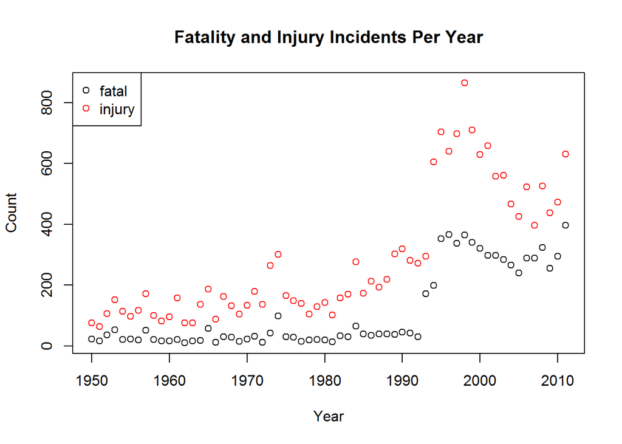

```r
fatal_subset <- subset(fatal_injury, fatal_injury$FATALITIES > 0)
fatal_year <- by_year(fatal_subset)

injury_subset <- subset(fatal_injury, fatal_injury$INJURIES > 0)
injury_year <- by_year(injury_subset)

injury_year <- cbind(injury_year, type="Injuries")
fatal_year <- cbind(fatal_year, type="Fatalities")
a_result<-rbind(fatal_year, injury_year)

plot(a_result$year, a_result$count, col=a_result$type, xlab="Year",ylab="Count",main="Fatality and Injury Incidents Per Year")
legend("topleft", legend=c("fatal","injury"), col=c(1,2), pch=1)
```

The graph shows a consistently higher level of injuries(red) over fatalities(black) and this would be consistent with a correlated pattern of first injuries and then injuries and death with increasing storm severity. We ascribe the sudden increase in observations in the mid 1990’s to increasing and better reporting of incidents. Evidence for this can be found in the tapering off of total levels in subsequent years at a higher level. This is different from levels of property incidents discussed next.

**Graph of Property and Crops**

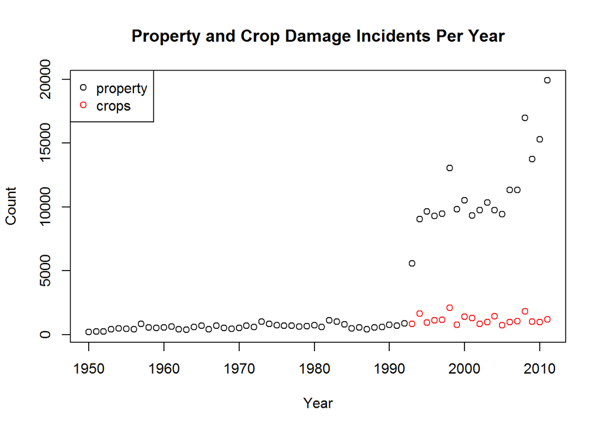

```r
property_subset <- subset(property_crop, property_crop$PROPDMG > 0)
property_year <- by_year(property_subset)

crop_subset <- subset(property_crop, property_crop$CROPDMG > 0)
crop_year <- by_year(crop_subset)

property_year <- cbind(property_year, type="Property")
crop_year <- cbind(crop_year, type="Crops")
a_result<-rbind(property_year, crop_year)

plot(a_result$year, a_result$count, col=a_result$type, xlab="Year",ylab="Count",main="Property and Crop Damage Incidents Per Year")
legend("topleft", legend=c("property","crops"), col=c(1,2), pch=1)
```

The crops data does not start until after 1990. There is a surge in reported property incidents from the mid 1990’s which then continues to increase. It is interesting that the number of property incidents has been on an increasing trend and it would be useful to know the cause(s) of this, for example whether housing is being developed in more dangerous areas, in order to form appropriate policies to possibly address this observed increase.